# People Based ML - Housing subsidy

Xiaoyi Wu

October 16, 2020

### Set Up

```r
options(scipen=10000000)

library(tidyverse)
library(kableExtra)
library(caret)
library(knitr)
library(pscl)
library(plotROC)
library(pROC)
library(lubridate)
library(stargazer)

root.dir = "https://raw.githubusercontent.com/urbanSpatial/Public-Policy-Analytics-Landing/master/DATA/"
source("https://raw.githubusercontent.com/urbanSpatial/Public-Policy-Analytics-Landing/master/functions.r")
```

```r
palette5 <- c("#981FAC","#CB0F8B","#FF006A","#FE4C35","#FE9900")
palette4 <- c("#981FAC","#FF006A","#FE4C35","#FE9900")
palette2 <- c("#981FAC","#FF006A")


housing_subsidy <- read.csv("housingSubsidy.csv")  %>%
    na.omit()
```

### 1 Motivation

The home repair tax credit program is important for governments to courage the residents to save energy and beneficial for residents to save money, Thus, it has been a popular policy in recent years.

However, when the Department of Housing and Community Development (HCD) reached out to eligible homeowners randomly, this may result in resource waste and work inefficiency because the government may allocate resource to homeowners who do not want to take the credits and ignore the homeowners who would like to take the credit.

This issue contributes to our motivation for this people-based prediction model to identify the risk/opportunity for potential clients. This model focuses on individual behavior and is based on logic model to predict if homeowners will take the credits or not. It also develops cost/benefit analysis to provide more accurate and efficient resource allocation method.

### 2 Feature importance/correlation

The x-axis is credit variable, which has two values. ‘Yes’ represents that the homeowner does take credit and ‘No’ represents he/she doesn’t. According to the bar plots below, we can see significant differences across credit and no_credit outcomes in ‘inflation_rate’(US Inflation Rate ) and ‘previous’(number of contacts before) subplots. The higher the inflation rate is in the US and the lower the number of previous contacts is, the less likely a homeowner will take the credit. And the ‘cons.price.idx’(Consumer price Index at campaign time) and ‘cons.conf.idx’(Consumer confidence index at time of campaign) also have great influence in probability density of homeowner taking credit.  
As for the categorical associations, the plots below suggests that people who has taken credit successfully before, get contacted in July and June, and don’t have mortgage tend to take the credit.

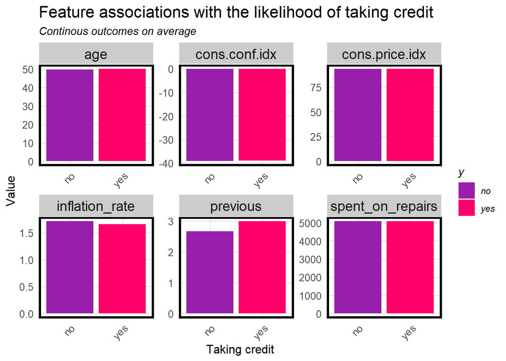

```r
housing_subsidy %>%
  dplyr::select(y,age,spent_on_repairs,inflation_rate,cons.conf.idx,cons.price.idx,previous) %>%
  gather(Variable, value, -y) %>%
   count(Variable, value, y) %>%
    ggplot(aes(y, value, fill=y)) +
      geom_bar(position = "dodge", stat = "summary", fun.y = "mean") +
      facet_wrap(~Variable, scales = "free") +
      scale_fill_manual(values = palette2) +
      labs(x="Taking credit", y="Value",
           title = "Feature associations with the likelihood of taking credit",
           subtitle = "Continous outcomes on average") +
  plotTheme() + theme(axis.text.x = element_text(angle = 45, hjust = 1))
```

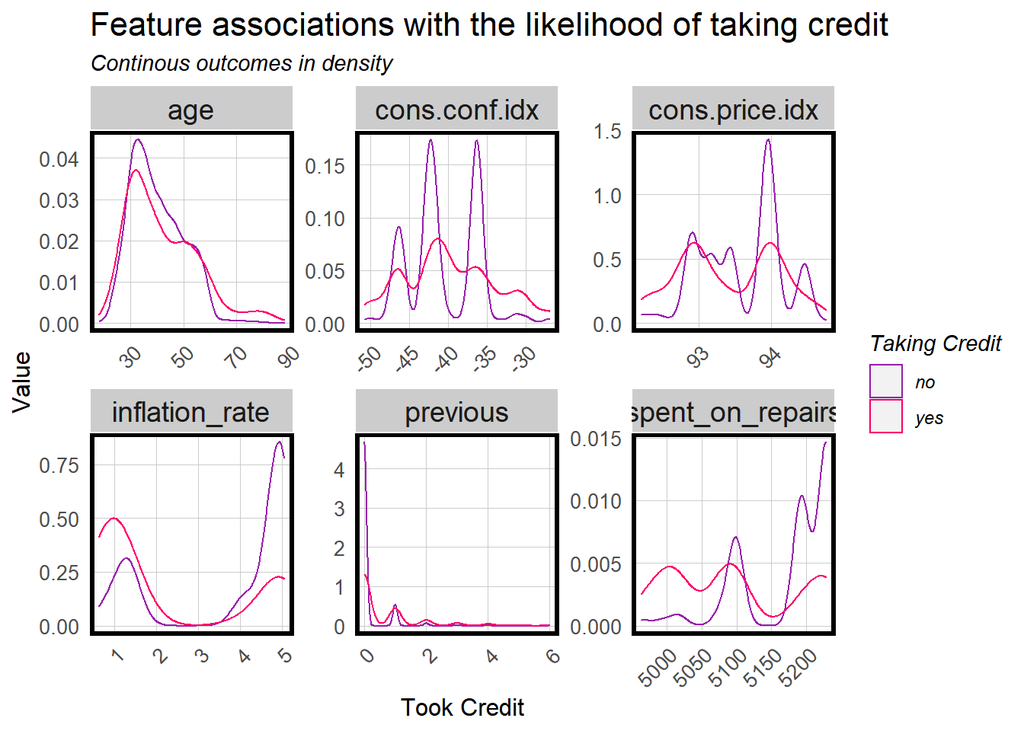

```r
housing_subsidy %>%
  dplyr::select(y,age,spent_on_repairs,inflation_rate,cons.conf.idx,cons.price.idx,previous) %>%
    gather(Variable, value, -y) %>%
    ggplot() +
    geom_density(aes(value, color=y), fill = "transparent") +
    facet_wrap(~Variable,  scales = "free") +
        scale_color_manual(values = palette2,
                          name = 'Taking Credit') +
    labs(x="Took Credit", y="Value",
           title = "Feature associations with the likelihood of taking credit",
           subtitle = "Continous outcomes in density" )+
     plotTheme() + theme(axis.text.x = element_text(angle = 45, hjust = 1))
```

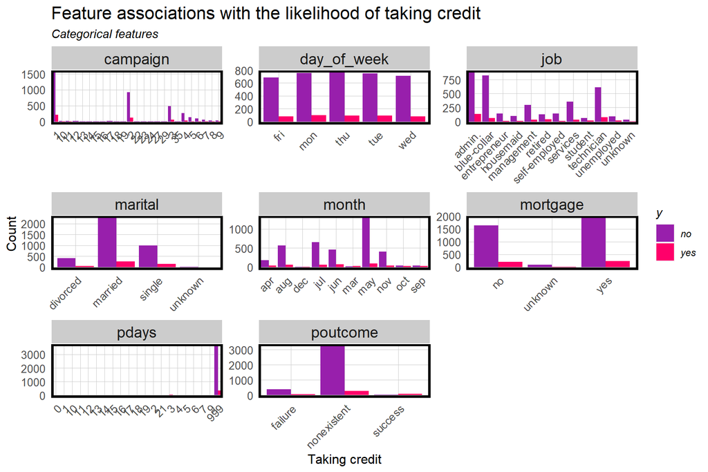

```r
housing_subsidy %>%
  dplyr::select(y, job, day_of_week,,month,campaign,pdays,marital,poutcome,mortgage) %>%
  gather(Variable, value, -y) %>%
  count(Variable, value, y) %>%
  ggplot(aes(value, n, fill = y)) +
    geom_bar(position = "dodge", stat="identity") +
    facet_wrap(~Variable, scales="free") +
    scale_fill_manual(values = palette2) +
    labs(x="Taking credit", y="Count",
         title = "Feature associations with the likelihood of taking credit",
         subtitle = "Categorical features") + theme(axis.text.x = element_text(angle = 45, hjust = 1)) +
  plotTheme()
```

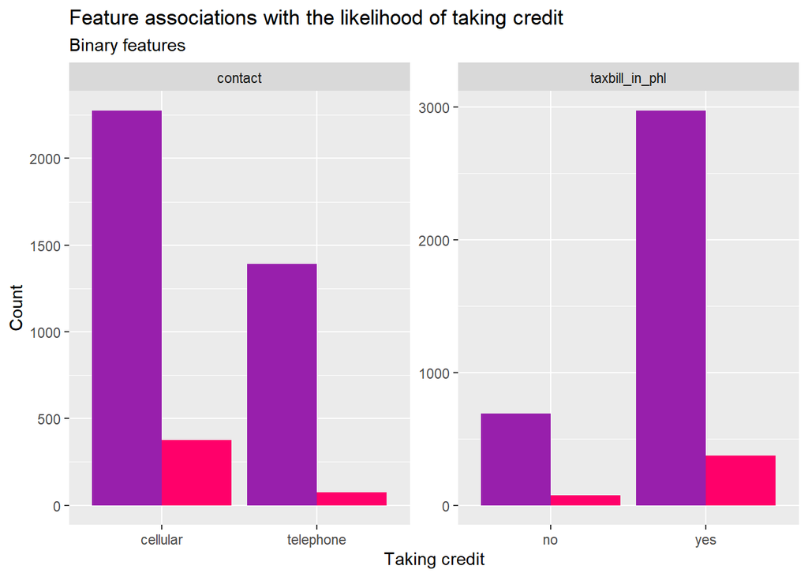

```r
housing_subsidy %>%
  dplyr::select(y,contact,taxbill_in_phl) %>%
  gather(Variable, value, -y) %>%
  count(Variable, value, y) %>%
  ggplot(aes(value, n, fill = y)) +
    geom_bar(position = "dodge", stat="identity") +
    facet_wrap(~Variable, scales="free") +
    scale_fill_manual(values = palette2) +
    labs(x="Taking credit", y="Count",
         title = "Feature associations with the likelihood of taking credit",
         subtitle = "Binary features") +
 theme(legend.position = "none")
```

#### create new feature

```r
housing_subsidy <- housing_subsidy%>%

  mutate(
         contact_time = case_when((pdays) < 180  ~ "short",
                                   (pdays) >= 180 & (pdays) < 365  ~ "mid",
                                   (pdays) >= 365 & (pdays) <= 999 ~ "long"),
         unemployed=ifelse(job=="unemployed",1,0),
         )
```

### 3 Split data into 65/35

A logistic regression model predicts a binary outcome - a `1` or a `0` - a `Taking credit` or a `No taking credit` and associates a coefficient that describes the change in the probability of the outcome given some change in the independent variable.

```r
set.seed(3456)
trainIndex <- createDataPartition(y=paste(housing_subsidy$y,housing_subsidy$taxLien), p = .650,
                                  list = FALSE,
                                  times = 1)

subsidyTrain <- housing_subsidy[ trainIndex,]
subsidyTest  <- housing_subsidy[-trainIndex,]
```

### 4 Sensitivity for model

We run our model with the dependent variable `y_numeric` and use all other variables to build kitche sink model and use ‘mortgage’, ‘month’,‘previous’,‘inflation_rate’, ‘spent_on_repairs’, ‘contact_time’, ‘unemployed’ to build a new model.

#### 4.1 kitchen sink model

```r
subsidyModel1<- glm(y_numeric ~ .,
                  data=subsidyTrain %>%
                    dplyr::select(-y),
                  family="binomial" (link="logit"))
summary(subsidyModel1)
```

```
##
## Call:
## glm(formula = y_numeric ~ ., family = binomial(link = "logit"),
##     data = subsidyTrain %>% dplyr::select(-y))
##
## Deviance Residuals:
##     Min       1Q   Median       3Q      Max
## -2.0282  -0.4101  -0.3118  -0.2344   2.9907
##
## Coefficients: (1 not defined because of singularities)
##                                   Estimate    Std. Error z value  Pr(>|z|)
## (Intercept)                  -125.46703126  152.62129730  -0.822  0.411031
## X                               0.00005080    0.00006164   0.824  0.409884
## age                             0.02093720    0.00874455   2.394  0.016652 *
## jobblue-collar                 -0.16685618    0.28108552  -0.594  0.552771
## jobentrepreneur                -0.52468484    0.50503281  -1.039  0.298845
## jobhousemaid                   -0.35374842    0.52306348  -0.676  0.498849
## jobmanagement                  -0.34275158    0.29761231  -1.152  0.249456
## jobretired                     -0.53316420    0.38213056  -1.395  0.162943
## jobself-employed               -0.69748797    0.45631594  -1.529  0.126384
## jobservices                    -0.13164717    0.29487081  -0.446  0.655267
## jobstudent                      0.13976618    0.45702329   0.306  0.759743
## jobtechnician                  -0.21275135    0.24614963  -0.864  0.387414
## jobunemployed                  -0.16200003    0.47910216  -0.338  0.735263
## jobunknown                      0.00281383    0.71953149   0.004  0.996880
## maritalmarried                  0.22054536    0.25299835   0.872  0.383358
## maritalsingle                   0.24612417    0.29207763   0.843  0.399415
## maritalunknown                  0.77802919    1.25006162   0.622  0.533684
## educationbasic.6y               0.65999793    0.41758877   1.580  0.113993
## educationbasic.9y               0.12364013    0.36718923   0.337  0.736328
## educationhigh.school            0.56585109    0.34109574   1.659  0.097132 .
## educationilliterate           -11.64700214  535.41151445  -0.022  0.982645
## educationprofessional.course    0.62345899    0.37311532   1.671  0.094731 .
## educationuniversity.degree      0.62467529    0.34574673   1.807  0.070802 .
## educationunknown               -0.10540648    0.49022986  -0.215  0.829756
## taxLienunknown                  0.06115623    0.22003966   0.278  0.781064
## taxLienyes                    -10.07190175  535.41153165  -0.019  0.984991
## mortgageunknown                -0.09640119    0.55387952  -0.174  0.861828
## mortgageyes                    -0.06776009    0.14848070  -0.456  0.648134
## taxbill_in_phlyes               0.21038398    0.20465498   1.028  0.303953
```

[output cut: 21 more lines]

```
## cons.conf.idx                   0.05457772    0.02790508   1.956  0.050485 .
## inflation_rate                 -0.26769457    0.45661216  -0.586  0.557699
## spent_on_repairs                0.01132411    0.01070671   1.058  0.290208
## contact_timeshort            -132.10077945   67.74725097  -1.950  0.051187 .
## unemployed                              NA            NA      NA        NA
## ---
## Signif. codes:  0 '***' 0.001 '**' 0.01 '*' 0.05 '.' 0.1 ' ' 1
##
## (Dispersion parameter for binomial family taken to be 1)
##
##     Null deviance: 1854  on 2679  degrees of freedom
## Residual deviance: 1411  on 2626  degrees of freedom
## AIC: 1519
##
## Number of Fisher Scoring iterations: 12
```

```r
pR2(subsidyModel1)[4]
```

```
## fitting null model for pseudo-r2
```

```
##  McFadden
## 0.2389058
```

#### 4.2 new model

```r
subsidygModel2 <- glm(y_numeric ~ .,
                  data=subsidyTrain %>%
                    dplyr::select(y_numeric,mortgage,month,previous,inflation_rate,spent_on_repairs,contact_time,unemployed),
                  family="binomial" (link="logit"))

summary(subsidygModel2)
```

```
##
## Call:
## glm(formula = y_numeric ~ ., family = binomial(link = "logit"),
##     data = subsidyTrain %>% dplyr::select(y_numeric, mortgage,
##         month, previous, inflation_rate, spent_on_repairs, contact_time,
##         unemployed))
##
## Deviance Residuals:
##     Min       1Q   Median       3Q      Max
## -1.8207  -0.3785  -0.3359  -0.2386   2.7030
##
## Coefficients:
##                    Estimate Std. Error z value    Pr(>|z|)
## (Intercept)       39.014771  13.877982   2.811    0.004935 **
## mortgageunknown   -0.215629   0.482471  -0.447    0.654928
## mortgageyes       -0.081353   0.143161  -0.568    0.569854
## monthaug           0.238885   0.314811   0.759    0.447959
## monthdec           1.538142   0.714037   2.154    0.031228 *
## monthjul           0.612807   0.329530   1.860    0.062937 .
## monthjun           0.552195   0.312606   1.766    0.077324 .
## monthmar           1.583856   0.436179   3.631    0.000282 ***
## monthmay          -0.621979   0.279584  -2.225    0.026104 *
## monthnov          -0.031970   0.347696  -0.092    0.926740
## monthoct          -0.206451   0.456950  -0.452    0.651412
## monthsep          -0.387211   0.486697  -0.796    0.426271
## previous           0.017046   0.130396   0.131    0.895993
## inflation_rate    -0.155310   0.125836  -1.234    0.217118
## spent_on_repairs  -0.007934   0.002757  -2.878    0.004005 **
## contact_timeshort  1.541401   0.302789   5.091 0.000000357 ***
## unemployed         0.095981   0.427965   0.224    0.822546
## ---
## Signif. codes:  0 '***' 0.001 '**' 0.01 '*' 0.05 '.' 0.1 ' ' 1
##
## (Dispersion parameter for binomial family taken to be 1)
##
##     Null deviance: 1854.0  on 2679  degrees of freedom
## Residual deviance: 1470.5  on 2663  degrees of freedom
## AIC: 1504.5
##
## Number of Fisher Scoring iterations: 6
```

```r
#the higher the better
pR2(subsidygModel2)[4]
```

```
## fitting null model for pseudo-r2
```

```
## McFadden
## 0.206834
```

#### 4.3 Cross validation

I run 100-fold cross validation and look at the ROC (aka AUC), Sensitivity and Specificity across this series of predicitons.

```r
ctrl <- trainControl(method = "cv", number = 100, classProbs=TRUE, summaryFunction=twoClassSummary)


cvFit1 <- train(y ~ ., data = housing_subsidy %>%
                  dplyr::select(-y_numeric) %>%
                  dplyr::mutate(y = ifelse(y=="no","c1.yes","c1.no")),
                method="glm", family="binomial",
                metric="ROC", trControl = ctrl)


cvFit1
```

```
## Generalized Linear Model
##
## 4119 samples
##   22 predictor
##    2 classes: 'c1.no', 'c1.yes'
##
## No pre-processing
## Resampling: Cross-Validated (100 fold)
## Summary of sample sizes: 4079, 4077, 4078, 4078, 4079, 4078, ...
## Resampling results:
##
##   ROC        Sens    Spec
##   0.7630071  0.2215  0.9806081
```

```r
cvFit2 <- train(y ~ ., data = housing_subsidy %>%
                      dplyr::select(y,mortgage,month,previous,inflation_rate,spent_on_repairs,contact_time,unemployed) %>%
                  dplyr::mutate(y = ifelse(y=="no","c2.yes","c2.no")),
                method="glm", family="binomial",
                metric="ROC", trControl = ctrl)
cvFit2
```

```
## Generalized Linear Model
##
## 4119 samples
##    7 predictor
##    2 classes: 'c2.no', 'c2.yes'
##
## No pre-processing
## Resampling: Cross-Validated (100 fold)
## Summary of sample sizes: 4078, 4078, 4078, 4078, 4077, 4078, ...
## Resampling results:
##
##   ROC        Sens   Spec
##   0.7750815  0.211  0.9825526
```

ROC is the proportion of the plotting area that is under the ROC curve. Sensitivity is the rate it correctly predicts homeowners of taking credits ( true positives ). Specificity is the rate it correctly predict homeowners of taking no credits ( the true negatives ).

However, the means are not as important as the across fold goodness of fit. The tighter each distribution is to its mean, the more generalizable the model.

According to plots below, We can clearly see that average ROCs of these two models are reasonable (between 0.5~1), but new featured model’s ROC distribution is tighter than that of kitchen sink model, which indicates the former is more generalizable.

The sensitivity values of these models are around 0.22 and distribute similarly, suggesting that the models both perform not well in predicting homeowner taking credits.

We do see high specificity values in these models, around 0.98 with similar tight distribution. It indicates that our models generalize well to the rate it correctly predicts homeowners who will not take credits.

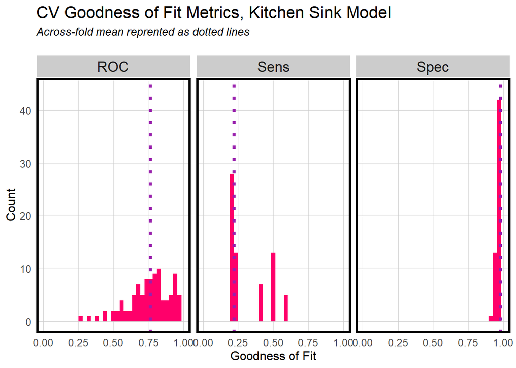

```r
dplyr::select(cvFit1$resample, -Resample) %>%
  gather(metric, value) %>%
  left_join(gather(cvFit1$results[2:4], metric, mean)) %>%
  ggplot(aes(value)) +
    geom_histogram(bins=35, fill = "#FF006A") +
    facet_wrap(~metric) +
    geom_vline(aes(xintercept = mean), colour = "#981FAC", linetype = 3, size = 1.5) +
    scale_x_continuous(limits = c(0, 1)) +
    labs(x="Goodness of Fit", y="Count",
         title="CV Goodness of Fit Metrics, Kitchen Sink Model",
         subtitle = "Across-fold mean reprented as dotted lines\n") +
  plotTheme()
```

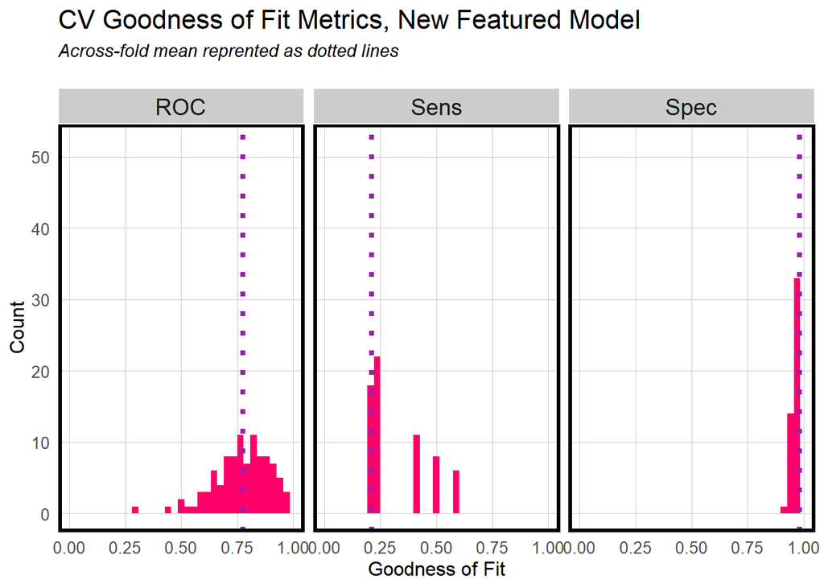

```r
dplyr::select(cvFit2$resample, -Resample) %>%
  gather(metric, value) %>%
  left_join(gather(cvFit2$results[2:4], metric, mean)) %>%
  ggplot(aes(value)) +
    geom_histogram(bins=35, fill = "#FF006A") +
    facet_wrap(~metric) +
    geom_vline(aes(xintercept = mean), colour = "#981FAC", linetype = 3, size = 1.5) +
    scale_x_continuous(limits = c(0, 1)) +
    labs(x="Goodness of Fit", y="Count",
         title="CV Goodness of Fit Metrics, New Featured Model",
         subtitle = "Across-fold mean reprented as dotted lines\n") +
    plotTheme()
```

### 5 ROC curve

The Receiver Operating Characteristic Curve or ROC Curve is useful because it visualizes trade-offs for two important confusion metrics. The y-axis is true positive rate, the rate we correctly predict people who will take credit. The x-axis is false positive rate, the rate we think the homeowners will take the credit but they will not actually. The trade-off between them will give us proper cost/benefit analysis and help us save money. Also, the usefulness of the algorithm can be judged by the proportion of the plotting area that is under the ROC curve. If the area is equal to one, it suggests the model over fit. If the area is equal to 0.5, this says the model fits poorly, considering the model will get wrong at 50% of the time. If the area is under 0.5, this indicate the model tends to predict the wrong credit at most time. Thus, only ROC between 0.5-1 is reasonable and suggests the model can predict people who would like to take credits in most time. The ROC output of our model is about 0.78. It suggests the model will predict credits correctly around 78% of the time. However, it will predict credits incorrectly more than 20% of the time.

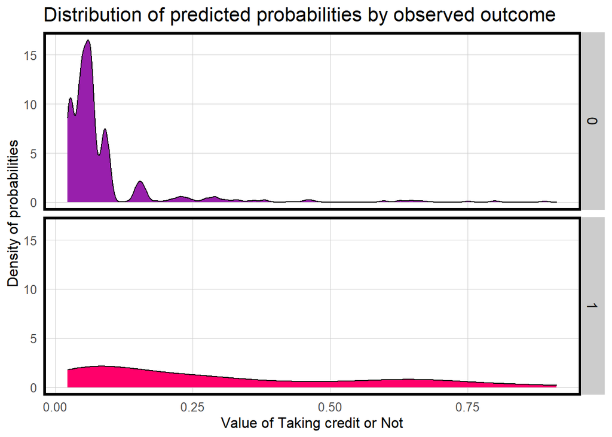

```r
testProbs <- data.frame(Outcome = as.factor(subsidyTest$y_numeric),
                        Probs = predict(subsidygModel2, subsidyTest, type= "response"))

ggplot(testProbs, aes(x = Probs, fill = as.factor(Outcome))) +
  geom_density() +
  facet_grid(Outcome ~ .) +
  scale_fill_manual(values = palette2) +
  labs(x = "Value of Taking credit or Not", y = "Density of probabilities",
       title = "Distribution of predicted probabilities by observed outcome") +plotTheme()+
  theme(strip.text.x = element_text(size = 18),
        legend.position = "none")
```

```r
testProbs <-
  testProbs %>%
  mutate(predOutcome  = as.factor(ifelse(testProbs$Probs > 0.5 , 1, 0)))
#a reasonable AUC is between 0.5 and 1.
pROC::auc(testProbs$Outcome, testProbs$Probs)
```

```
## Area under the curve: 0.7739
```

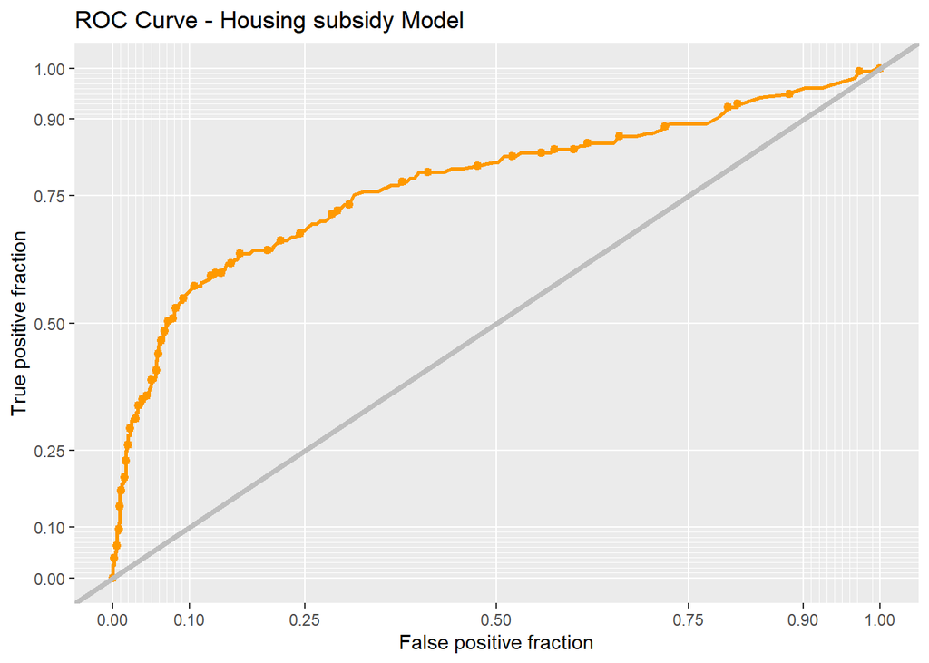

```r
ggplot(testProbs, aes(d = as.numeric(testProbs$Outcome), m = Probs)) +
  geom_roc(n.cuts = 50, labels = FALSE, colour = "#FE9900") +
  style_roc(theme = theme_grey) +
  geom_abline(slope = 1, intercept = 0, size = 1.5, color = 'grey') +
  labs(title = "ROC Curve - Housing subsidy Model")
```

### 6 Cost-Benefit

#### 6.2 Cost/Benefit Table

```r
cost_benefit_table <-
   testProbs %>%
      count(predOutcome, Outcome) %>%
      summarize(True_Negative = sum(n[predOutcome==0 & Outcome==0]),
                True_Positive = sum(n[predOutcome==1 & Outcome==1]),
                False_Negative = sum(n[predOutcome==0 & Outcome==1]),
                False_Positive = sum(n[predOutcome==1 & Outcome==0])) %>%
       gather(Variable, Count) %>%
       mutate(Revenue =
               ifelse(Variable == "True_Negative", 0 * Count,
               ifelse(Variable == "True_Positive",((-5000 - 2850 + (10000 + 56000)) * Count * 0.25 + (- 2850) * Count * 0.75),
               ifelse(Variable == "False_Negative", 0 * Count,
               ifelse(Variable == "False_Positive", (- 2850) * Count, 0))))) %>%
    bind_cols(data.frame(Description = c(
              "Predicted correctly homeowner would not take the credit",
              "Predicted correctly homeowner would take the credit s",
              "Predicted incorrectly homeowner would not take the credit",
              "Predicted incorrectly homeowner would take the credit")))

kable(cost_benefit_table,caption='Cost/Benifit Table') %>% kable_styling(font_size = 12,
                bootstrap_options = c("striped", "hover", "condensed"))
```

Cost/Benifit Table

| Variable | Count | Revenue | Description |
| --- | --- | --- | --- |
| True_Negative | 1260 | 0 | Predicted correctly homeowner would not take the credit |
| True_Positive | 38 | 471200 | Predicted correctly homeowner would take the credit s |
| False_Negative | 119 | 0 | Predicted incorrectly homeowner would not take the credit |
| False_Positive | 22 | -62700 | Predicted incorrectly homeowner would take the credit |

### 6.4 Threhold

```r
iterateThresholds <- function(data) {
  x = .01
  all_prediction <- data.frame()
  while (x <= 1) {

  this_prediction <-
      testProbs %>%
      mutate(predOutcome = ifelse(Probs > x, 1, 0)) %>%
      count(predOutcome, Outcome) %>%
      summarize(True_Negative = sum(n[predOutcome==0 & Outcome==0]),
                True_Positive = sum(n[predOutcome==1 & Outcome==1]),
                False_Negative = sum(n[predOutcome==0 & Outcome==1]),
                False_Positive = sum(n[predOutcome==1 & Outcome==0])) %>%
     gather(Variable, Count) %>%
     mutate(Revenue =
              ifelse(Variable == "True_Negative", Count,
               ifelse(Variable == "True_Positive",((-5000 - 2850 + (10000 + 56000)) * Count * 0.25 + (- 2850) * Count * 0.75),
               ifelse(Variable == "False_Negative", 0 * Count,
               ifelse(Variable == "False_Positive", (- 2850) * Count, 0)))),
            Threshold = x)

  all_prediction <- rbind(all_prediction, this_prediction)
  x <- x + .01
  }
return(all_prediction)
}
```

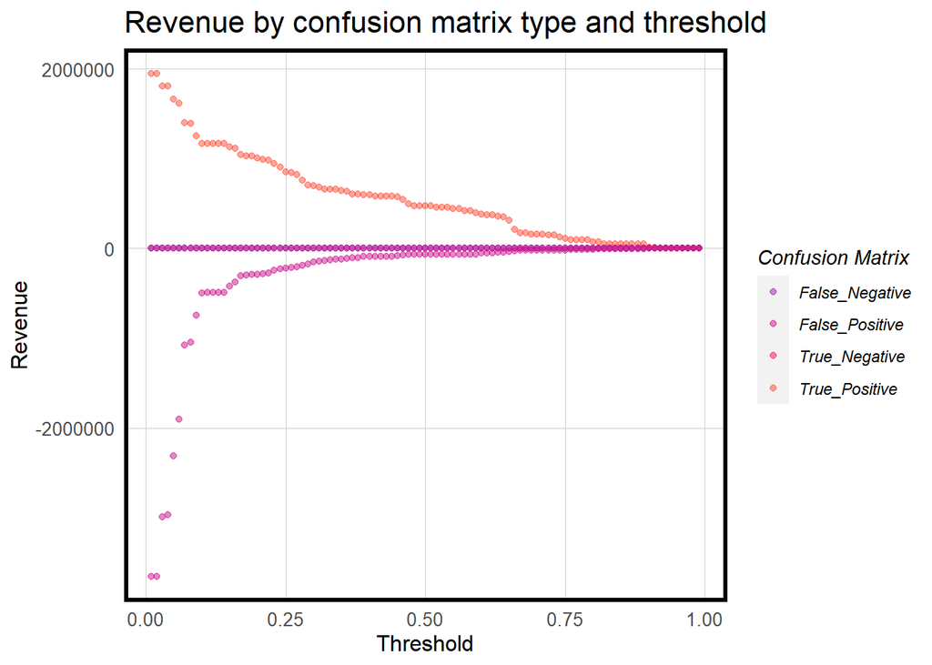

```r
whichThreshold <- iterateThresholds(testProbs)

whichThreshold2<-whichThreshold %>%
    mutate(total_count =
               ifelse(Variable == "True_Positive", Count * 0.25,
               ifelse(Variable == 'False_Negative', Count ,0 ))) %>%
    group_by(Threshold) %>%
    summarize(Total_Revenue = sum(Revenue),
              Total_Count_of_Credits = sum(total_count))

whichThreshold %>%
  ggplot(.,aes(Threshold, Revenue, colour = Variable)) +
  geom_point(alpha=.5) +
  scale_colour_manual(values = palette5[c(1:5)]) +
  labs(title = "Revenue by confusion matrix type and threshold",
       y = "Revenue") +
  plotTheme() +
  guides(colour=guide_legend(title = "Confusion Matrix"))
```

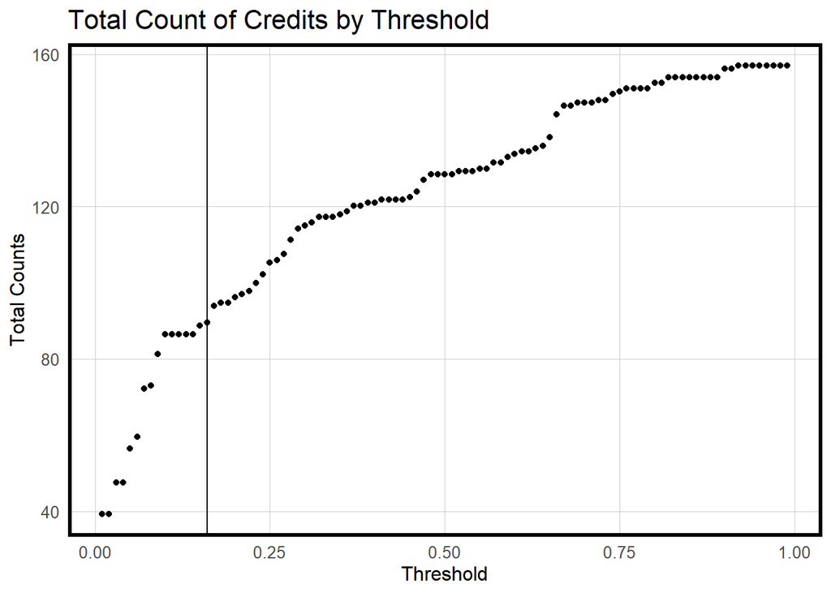

```r
whichThreshold2 %>%

  ggplot(aes(Threshold, Total_Count_of_Credits)) +
    geom_point() +
    geom_vline(xintercept = pull(arrange(whichThreshold2, -Total_Revenue)[1,1])) +
  ylab('Total Counts')  +
  labs(title = "Total Count of Credits by Threshold")  +
 plotTheme()
```

[figure not shown]

```r
whichThreshold2 %>%

  ggplot(aes(Threshold, Total_Revenue)) +
    geom_point() +
    geom_vline(xintercept = pull(arrange(whichThreshold2, -Total_Revenue)[1,1])) +
  ylab('Total Counts')  +
  labs(title = "Total Count of Credits by Threshold")  +
 plotTheme()
```

```r
index=which.max(whichThreshold2$Total_Revenue)
bind_table <- rbind(whichThreshold2[50,],whichThreshold2[index,])
kable(bind_table,caption='0.5 Threshold and Optimal Threshod') %>% kable_styling(font_size = 12,
                bootstrap_options = c("striped", "hover", "condensed"))
```

0.5 Threshold and Optimal Threshod

| Threshold | Total_Revenue | Total_Count_of_Credits |
| --- | --- | --- |
| 0.50 | 409760 | 128.5 |
| 0.16 | 740950 | 89.5 |

### 7 Conclusion

Compared to 0.5 threshold, which indicates the Coin Flip situation, my model does earn more than 260000 dollars for the government. The ROC value of the model is around 0.78 and thus is reasonable.However, it still needs further development before it is put into production.  
Firstly,the McFadden R-Squared for the model is still very low, near 0.22.  
Also from the confusion metric, we can clearly see that even model is successful to predict homeowners who will not take credits and has high specificity, but it is hard to predict homeowner who would love to take credits with low sensitivity.The later is important for the government, considering they try to encourage people to take credit and allocate corresponding resources.  
To improve this model, surveys based on homeowners’ house condition and financial condition needed to be conducted. The dataset needs to include more observation related to homeowners who have taken credits to make even distribution. Also, it needs more variables regarding the household income, household composition, physical characters of house, and spatial location to make better prediction. What’s more, there may exist spatial equivalents of spatial lag in our models. Thus, how to eliminate spatial errors can be a key problem.